# Analysis the effect of sever wearher on population health and economic

Siqi Zhu

December 23, 2015

### Synopsis

Storms and other severe weather events can cause both public health and economic problems for communities and municipalities. Many severe events can result in fatalities, injuries, and property damage, and preventing such outcomes to the extent possible is a key concern.This project involves exploring the U.S. National Oceanic and Atmospheric Administration’s (NOAA) storm database. And try to figure out which types of events (as indicated in the EVTYPE variable) are most harmful with respect to population health, and which types of events have the greatest economic consequences.

```r
library(ggplot2)
library(dplyr)
library(plyr)
require(gridExtra)
```

### Data Processing

Import data from internet, read and clean data before analysis.

```r
fileurl = 'http://d396qusza40orc.cloudfront.net/repdata%2Fdata%2FStormData.csv.bz2'
dest = "/Users/zhusiqi/Desktop/coursera/R_jhu/reproducible_research/peer_assesment_2/StormData.csv.bz2"
if(!file.exists(dest)){
  download.file(fileurl, dest)
}
data.raw = read.csv(bzfile(dest))
head(data.raw, 3)
```

```
##   STATE__          BGN_DATE BGN_TIME TIME_ZONE COUNTY COUNTYNAME STATE
## 1       1 4/18/1950 0:00:00     0130       CST     97     MOBILE    AL
## 2       1 4/18/1950 0:00:00     0145       CST      3    BALDWIN    AL
## 3       1 2/20/1951 0:00:00     1600       CST     57    FAYETTE    AL
##    EVTYPE BGN_RANGE BGN_AZI BGN_LOCATI END_DATE END_TIME COUNTY_END
## 1 TORNADO         0                                               0
## 2 TORNADO         0                                               0
## 3 TORNADO         0                                               0
##   COUNTYENDN END_RANGE END_AZI END_LOCATI LENGTH WIDTH F MAG FATALITIES
## 1         NA         0                      14.0   100 3   0          0
## 2         NA         0                       2.0   150 2   0          0
## 3         NA         0                       0.1   123 2   0          0
##   INJURIES PROPDMG PROPDMGEXP CROPDMG CROPDMGEXP WFO STATEOFFIC ZONENAMES
## 1       15    25.0          K       0
## 2        0     2.5          K       0
## 3        2    25.0          K       0
##   LATITUDE LONGITUDE LATITUDE_E LONGITUDE_ REMARKS REFNUM
## 1     3040      8812       3051       8806              1
## 2     3042      8755          0          0              2
## 3     3340      8742          0          0              3
```

```r
data = data.raw[,c("EVTYPE","FATALITIES","INJURIES","PROPDMG","PROPDMGEXP","CROPDMG","CROPDMGEXP")]
data$EVTYPE <- tolower(data$EVTYPE)
data$EVTYPE[grepl("*astronomical low tide*", data$EVTYPE)] <- "Astronomical Low Tide"
data$EVTYPE[grepl("*avalanc(h)?e*", data$EVTYPE)] <- "Avalanche"
data$EVTYPE[grepl("*blizzard*", data$EVTYPE)] <- "Blizzard"
data$EVTYPE[grepl("*coastal flood*", data$EVTYPE)] <- "Coastal Flood"
data$EVTYPE[grepl("*cold/wind chill*", data$EVTYPE)] <- "Cold/Wind Chill"
data$EVTYPE[grepl("*debris flow*|mud( )?slide*|*landslide*|*rock slide*", data$EVTYPE)] <- "Debris Flow"
data$EVTYPE[grepl("*(dense )?fog*", data$EVTYPE)] <- "Dense Fog"
data$EVTYPE[grepl("*dense smoke*", data$EVTYPE)] <- "Dense Smoke"
data$EVTYPE[grepl("*drought*", data$EVTYPE)] <- "Drought"
data$EVTYPE[grepl("*dust devil*", data$EVTYPE)] <- "Dust Devil"
data$EVTYPE[grepl("*dust storm*", data$EVTYPE)] <- "Dust Storm"
data$EVTYPE[grepl("*excessive heat*|*extreme heat*", data$EVTYPE)] <- "Excessive Heat"
data$EVTYPE[grepl("*extreme cold/wind chill*", data$EVTYPE)] <- "Extreme Cold/Wind Chill"
data$EVTYPE[grepl("*flash flood*|*flash/flood*|*flood/flash*|*flashflood*|*flood flash*", data$EVTYPE)] <- "Flash Flood"
data$EVTYPE[grepl("*lakeshore flood*", data$EVTYPE)] <- "Lakeshore Flood"
data$EVTYPE[grepl("*flood*", data$EVTYPE)] <- "Flood"
data$EVTYPE[grepl("*frost*|*frost/freeze*|*freeze*", data$EVTYPE)] <- "Frost/Freeze"
data$EVTYPE[grepl("*funnel cloud*", data$EVTYPE)] <- "Funnel Cloud"
data$EVTYPE[grepl("*freezing fog*", data$EVTYPE)] <- "Freezing Fog"
data$EVTYPE[grepl("*marine hail*", data$EVTYPE)] <- "Marine Hail"
data$EVTYPE[grepl("*hail*", data$EVTYPE)] <- "Hail"
data$EVTYPE[grepl("*heat*", data$EVTYPE)] <- "Heat"
data$EVTYPE[grepl("*heavy rain*", data$EVTYPE)] <- "Heavy Rain"
data$EVTYPE[grepl("*heavy snow*", data$EVTYPE)] <- "Heavy Snow"
data$EVTYPE[grepl("*high surf*|*high seas*|*high waves*|*high swells*|*rough seas*|*rough surf*", data$EVTYPE)] <- "High Surf"
data$EVTYPE[grepl("*marine high wind*", data$EVTYPE)] <- "Marine High Wind"
data$EVTYPE[grepl("*high wind*", data$EVTYPE)] <- "High Wind"
data$EVTYPE[grepl("*hurricane*|*typhoon*", data$EVTYPE)] <- "Hurricane (Typhoon)"
data$EVTYPE[grepl("*ice storm*", data$EVTYPE)] <- "Ice Storm"
data$EVTYPE[grepl("*lake effect snow*", data$EVTYPE)] <- "Lake-Effect Snow"
data$EVTYPE[grepl("*lig(h)?t(n)?ing*", data$EVTYPE)] <- "Lightning"
data$EVTYPE[grepl("*marine strong wind*", data$EVTYPE)] <- "Marine Strong Wind"
data$EVTYPE[grepl("*marine thunderstorm wind*", data$EVTYPE)] <- "Marine Thunderstorm Wind"
data$EVTYPE[grepl("*rip current*", data$EVTYPE)] <- "Rip Current"
data$EVTYPE[grepl("*seiche*", data$EVTYPE)] <- "Seiche"
data$EVTYPE[grepl("*sleet*", data$EVTYPE)] <- "Sleet"
data$EVTYPE[grepl("*storm surge/tide*|*storm surge*", data$EVTYPE)] <- "Storm Surge/Tide"
data$EVTYPE[grepl("*strong wind*", data$EVTYPE)] <- "Strong Wind"
data$EVTYPE[grepl("*t(h)?u(n)?(d)?e(e)?r(e)?(s)?torm*|*tstm*|*thunderstrom*", data$EVTYPE)] <- "Thunderstorm Wind"
data$EVTYPE[grepl("*torn(a)?do*", data$EVTYPE)] <- "Tornado"
data$EVTYPE[grepl("*tropical depression*", data$EVTYPE)] <- "Tropical Depression"
data$EVTYPE[grepl("*tropical storm*", data$EVTYPE)] <- "Tropical Storm"
data$EVTYPE[grepl("*tsunami*", data$EVTYPE)] <- "Tsunami"
data$EVTYPE[grepl("*volcanic ash*", data$EVTYPE)] <- "Volcanic Ash"
data$EVTYPE[grepl("*waterspout*", data$EVTYPE)] <- "Waterspout"
data$EVTYPE[grepl("*wild( )?fire*|*wild/forest fire*|*brush fire*|*forest fire*", data$EVTYPE)] <- "Wildfire"
data$EVTYPE[grepl("*winter storm*", data$EVTYPE)] <- "Winter Storm"
data$EVTYPE[grepl("*winter weather*", data$EVTYPE)] <- "Winter Weather"
```

```r
# Caululate the sum of events and group according to the types of events.
data.sort = function(name, data.new = data, top = 5){
        data.new = subset(data.new, name > 0)
        col.num = which(colnames(data.new) == name)
        data.new = aggregate(data.new[,col.num], by=list(data.new$EVTYPE), FUN = "sum")
        data.new = arrange(data.new, data.new[,2], decreasing = TRUE)
        data.new = head(data.new, top)
        colnames(data.new) = c('EVTYPE', 'COUNT')
        data.new = within(data.new, EVTYPE  <-  factor(x = EVTYPE, levels = data.new$EVTYPE))
        return(data.new)
}

# Calculate total number of PROPDMG and CROPDMG.
data.total <- function(name, data.new = data){
        col.num <- which(colnames(data.new) == name)
        data.new[, col.num] <- as.character(data.new[, col.num])
        data.new[toupper(data.new[, col.num]) == "B", col.num] <- "9"
        data.new[toupper(data.new[, col.num]) == "M", col.num] <- "6"
        data.new[toupper(data.new[, col.num]) == "K", col.num] <- "3"
        data.new[toupper(data.new[, col.num]) == "H", col.num] <- "2"
        data.new[data.new[, col.num] == "", col.num] <- "0"
        data.new[, col.num] <- as.numeric(data.new[, col.num])
        data.new[is.na(data.new[, col.num]), col.num] <- 0
        if (name == 'PROPDMGEXP'){
                data.new$PROPDMG.total = data.new$PROPDMG * 10 ^ data.new$PROPDMGEXP
                total = data.new[, colnames(data.new) == 'PROPDMG.total']
                result = cbind(data.new['EVTYPE'], total)
                return(result)
        }
        if (name == 'CROPDMGEXP'){
                data.new$CROPDMG.total = data.new$CROPDMG * 10 ^ data.new$CROPDMGEXP
                total = data.new[, colnames(data.new) == 'CROPDMG.total']
                result = cbind(data.new['EVTYPE'], total)
                return(result)
        }
}
```

### Results

#### Question 1: Across the United States, which types of events (as indicated in the EVTYPE variable) are most harmful with respect to population health?

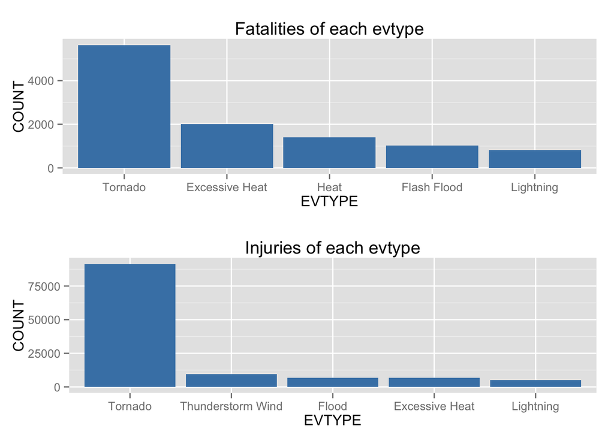

```r
FATALITIES.count = data.sort('FATALITIES')
INJURIES.count = data.sort('INJURIES')
plot.1 = ggplot(FATALITIES.count, aes(x = EVTYPE, y = COUNT)) + geom_histogram(stat = 'identity', fill = 'steelblue') + labs(title = 'Fatalities of each evtype')
plot.2 = ggplot(INJURIES.count, aes(x = EVTYPE, y = COUNT)) + geom_histogram(stat = 'identity', fill = 'steelblue') + labs(title = 'Injuries of each evtype')
grid.arrange(plot.1, plot.2, nrow = 2)
```

We use **FATALITIES** and **INJURIES** represent population health condition. As we can see from the figure, **Tornade** have largest effect on population health.

#### Question 2: Across the United States, which types of events have the greatest economic consequences?

```r
prop = data.total('PROPDMGEXP')
crop = data.total('CROPDMGEXP')
```

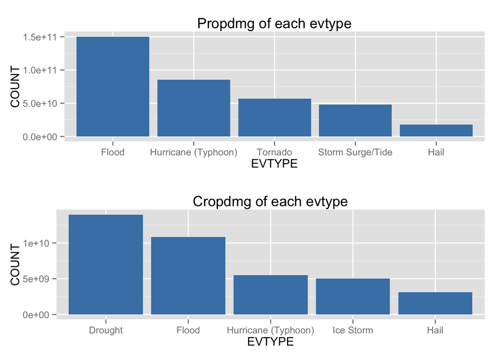

```r
prop.count = data.sort('total', prop, 5)
crop.count = data.sort('total', crop, 5)
plot.3 = ggplot(prop.count, aes(x = EVTYPE, y = COUNT)) + geom_histogram(stat = 'identity', fill = 'steelblue') + labs(title = 'Propdmg of each evtype')
plot.4 = ggplot(crop.count, aes(x = EVTYPE, y = COUNT)) + geom_histogram(stat = 'identity', fill = 'steelblue') + labs(title = 'Cropdmg of each evtype')
grid.arrange(plot.3, plot.4, nrow = 2)
```